# Optimal Treatment Analysis

## Outcome Variable

**Outcome Variable:** whz

## Predictor Variables

**Intervention Variable:** month

**Adjustment Set:**

unadjusted

## Stratifying Variables

The analysis was stratified on these variable(s):

- agecat
- studyid
- country

## Data Summary

| agecat | studyid | country | month | n_cell | n |
| --- | --- | --- | --- | --- | --- |
| Birth | ki0047075b-MAL-ED | BANGLADESH | 1 | 20 | 215 |
| Birth | ki0047075b-MAL-ED | BANGLADESH | 2 | 18 | 215 |
| Birth | ki0047075b-MAL-ED | BANGLADESH | 3 | 23 | 215 |
| Birth | ki0047075b-MAL-ED | BANGLADESH | 4 | 21 | 215 |
| Birth | ki0047075b-MAL-ED | BANGLADESH | 5 | 17 | 215 |
| Birth | ki0047075b-MAL-ED | BANGLADESH | 6 | 6 | 215 |
| Birth | ki0047075b-MAL-ED | BANGLADESH | 7 | 12 | 215 |
| Birth | ki0047075b-MAL-ED | BANGLADESH | 8 | 24 | 215 |
| Birth | ki0047075b-MAL-ED | BANGLADESH | 9 | 16 | 215 |
| Birth | ki0047075b-MAL-ED | BANGLADESH | 10 | 19 | 215 |
| Birth | ki0047075b-MAL-ED | BANGLADESH | 11 | 13 | 215 |
| Birth | ki0047075b-MAL-ED | BANGLADESH | 12 | 26 | 215 |
| Birth | ki0047075b-MAL-ED | BRAZIL | 1 | 5 | 62 |
| Birth | ki0047075b-MAL-ED | BRAZIL | 2 | 8 | 62 |
| Birth | ki0047075b-MAL-ED | BRAZIL | 3 | 9 | 62 |
| Birth | ki0047075b-MAL-ED | BRAZIL | 4 | 5 | 62 |
| Birth | ki0047075b-MAL-ED | BRAZIL | 5 | 1 | 62 |
| Birth | ki0047075b-MAL-ED | BRAZIL | 6 | 5 | 62 |
| Birth | ki0047075b-MAL-ED | BRAZIL | 7 | 5 | 62 |
| Birth | ki0047075b-MAL-ED | BRAZIL | 8 | 6 | 62 |
| Birth | ki0047075b-MAL-ED | BRAZIL | 9 | 6 | 62 |
| Birth | ki0047075b-MAL-ED | BRAZIL | 10 | 4 | 62 |
| Birth | ki0047075b-MAL-ED | BRAZIL | 11 | 5 | 62 |
| Birth | ki0047075b-MAL-ED | BRAZIL | 12 | 3 | 62 |
| Birth | ki0047075b-MAL-ED | INDIA | 1 | 2 | 45 |
| Birth | ki0047075b-MAL-ED | INDIA | 2 | 3 | 45 |
| Birth | ki0047075b-MAL-ED | INDIA | 3 | 5 | 45 |
| Birth | ki0047075b-MAL-ED | INDIA | 4 | 6 | 45 |
| Birth | ki0047075b-MAL-ED | INDIA | 5 | 2 | 45 |
| Birth | ki0047075b-MAL-ED | INDIA | 6 | 3 | 45 |

[output cut: 774 more lines]

The following strata were considered:

- agecat: 24 months, studyid: ki0047075b-MAL-ED, country: BANGLADESH
- agecat: 24 months, studyid: ki0047075b-MAL-ED, country: BRAZIL
- agecat: 24 months, studyid: ki0047075b-MAL-ED, country: INDIA
- agecat: 24 months, studyid: ki0047075b-MAL-ED, country: NEPAL
- agecat: 24 months, studyid: ki0047075b-MAL-ED, country: PERU
- agecat: 24 months, studyid: ki0047075b-MAL-ED, country: SOUTH AFRICA
- agecat: 24 months, studyid: ki0047075b-MAL-ED, country: TANZANIA, UNITED REPUBLIC OF
- agecat: 24 months, studyid: ki1000108-CMC-V-BCS-2002, country: INDIA
- agecat: 24 months, studyid: ki1000108-IRC, country: INDIA
- agecat: 24 months, studyid: ki1000109-EE, country: PAKISTAN
- agecat: 24 months, studyid: ki1017093-NIH-Birth, country: BANGLADESH
- agecat: 24 months, studyid: ki1066203-TanzaniaChild2, country: TANZANIA, UNITED REPUBLIC OF
- agecat: 24 months, studyid: ki1101329-Keneba, country: GAMBIA
- agecat: 24 months, studyid: ki1113344-GMS-Nepal, country: NEPAL
- agecat: 24 months, studyid: ki1114097-CMIN, country: BANGLADESH
- agecat: 24 months, studyid: ki1114097-CONTENT, country: PERU
- agecat: 24 months, studyid: ki1119695-PROBIT, country: BELARUS
- agecat: 24 months, studyid: ki1126311-ZVITAMBO, country: ZIMBABWE
- agecat: 24 months, studyid: ki1148112-LCNI-5, country: MALAWI
- agecat: 24 months, studyid: kiGH5241-JiVitA-3, country: BANGLADESH
- agecat: 24 months, studyid: kiGH5241-JiVitA-4, country: BANGLADESH
- agecat: 6 months, studyid: ki0047075b-MAL-ED, country: BANGLADESH
- agecat: 6 months, studyid: ki0047075b-MAL-ED, country: BRAZIL
- agecat: 6 months, studyid: ki0047075b-MAL-ED, country: INDIA
- agecat: 6 months, studyid: ki0047075b-MAL-ED, country: NEPAL
- agecat: 6 months, studyid: ki0047075b-MAL-ED, country: PERU
- agecat: 6 months, studyid: ki0047075b-MAL-ED, country: SOUTH AFRICA
- agecat: 6 months, studyid: ki0047075b-MAL-ED, country: TANZANIA, UNITED REPUBLIC OF
- agecat: 6 months, studyid: ki1000108-CMC-V-BCS-2002, country: INDIA
- agecat: 6 months, studyid: ki1000108-IRC, country: INDIA
- agecat: 6 months, studyid: ki1000109-EE, country: PAKISTAN
- agecat: 6 months, studyid: ki1000109-ResPak, country: PAKISTAN
- agecat: 6 months, studyid: ki1000304b-SAS-CompFeed, country: INDIA
- agecat: 6 months, studyid: ki1000304b-SAS-FoodSuppl, country: INDIA
- agecat: 6 months, studyid: ki1017093-NIH-Birth, country: BANGLADESH
- agecat: 6 months, studyid: ki1066203-TanzaniaChild2, country: TANZANIA, UNITED REPUBLIC OF
- agecat: 6 months, studyid: ki1101329-Keneba, country: GAMBIA
- agecat: 6 months, studyid: ki1112895-Guatemala BSC, country: GUATEMALA
- agecat: 6 months, studyid: ki1113344-GMS-Nepal, country: NEPAL
- agecat: 6 months, studyid: ki1114097-CMIN, country: BANGLADESH
- agecat: 6 months, studyid: ki1114097-CONTENT, country: PERU
- agecat: 6 months, studyid: ki1119695-PROBIT, country: BELARUS
- agecat: 6 months, studyid: ki1126311-ZVITAMBO, country: ZIMBABWE
- agecat: 6 months, studyid: ki1148112-LCNI-5, country: MALAWI
- agecat: 6 months, studyid: kiGH5241-JiVitA-3, country: BANGLADESH
- agecat: 6 months, studyid: kiGH5241-JiVitA-4, country: BANGLADESH
- agecat: Birth, studyid: ki0047075b-MAL-ED, country: BANGLADESH
- agecat: Birth, studyid: ki0047075b-MAL-ED, country: BRAZIL
- agecat: Birth, studyid: ki0047075b-MAL-ED, country: INDIA
- agecat: Birth, studyid: ki0047075b-MAL-ED, country: NEPAL
- agecat: Birth, studyid: ki0047075b-MAL-ED, country: PERU
- agecat: Birth, studyid: ki0047075b-MAL-ED, country: SOUTH AFRICA
- agecat: Birth, studyid: ki0047075b-MAL-ED, country: TANZANIA, UNITED REPUBLIC OF
- agecat: Birth, studyid: ki1000108-CMC-V-BCS-2002, country: INDIA
- agecat: Birth, studyid: ki1000108-IRC, country: INDIA
- agecat: Birth, studyid: ki1000109-EE, country: PAKISTAN
- agecat: Birth, studyid: ki1000109-ResPak, country: PAKISTAN
- agecat: Birth, studyid: ki1000304b-SAS-CompFeed, country: INDIA
- agecat: Birth, studyid: ki1017093-NIH-Birth, country: BANGLADESH
- agecat: Birth, studyid: ki1101329-Keneba, country: GAMBIA
- agecat: Birth, studyid: ki1113344-GMS-Nepal, country: NEPAL
- agecat: Birth, studyid: ki1114097-CMIN, country: BANGLADESH
- agecat: Birth, studyid: ki1114097-CONTENT, country: PERU
- agecat: Birth, studyid: ki1119695-PROBIT, country: BELARUS
- agecat: Birth, studyid: ki1126311-ZVITAMBO, country: ZIMBABWE
- agecat: Birth, studyid: kiGH5241-JiVitA-3, country: BANGLADESH
- agecat: Birth, studyid: kiGH5241-JiVitA-4, country: BANGLADESH

### Dropped Strata

Some strata were dropped due to rare outcomes:

- agecat: Birth, studyid: ki0047075b-MAL-ED, country: BRAZIL
- agecat: Birth, studyid: ki0047075b-MAL-ED, country: INDIA
- agecat: Birth, studyid: ki0047075b-MAL-ED, country: NEPAL
- agecat: Birth, studyid: ki0047075b-MAL-ED, country: SOUTH AFRICA
- agecat: Birth, studyid: ki0047075b-MAL-ED, country: TANZANIA, UNITED REPUBLIC OF
- agecat: Birth, studyid: ki1000108-CMC-V-BCS-2002, country: INDIA
- agecat: Birth, studyid: ki1000109-EE, country: PAKISTAN
- agecat: Birth, studyid: ki1000109-ResPak, country: PAKISTAN
- agecat: Birth, studyid: ki1113344-GMS-Nepal, country: NEPAL
- agecat: Birth, studyid: ki1114097-CMIN, country: BANGLADESH
- agecat: Birth, studyid: ki1114097-CONTENT, country: PERU
- agecat: Birth, studyid: kiGH5241-JiVitA-4, country: BANGLADESH
- agecat: 6 months, studyid: ki1000109-EE, country: PAKISTAN
- agecat: 6 months, studyid: ki1000109-ResPak, country: PAKISTAN
- agecat: 6 months, studyid: ki1000304b-SAS-FoodSuppl, country: INDIA
- agecat: 6 months, studyid: ki1113344-GMS-Nepal, country: NEPAL
- agecat: 6 months, studyid: ki1114097-CMIN, country: BANGLADESH
- agecat: 24 months, studyid: ki1000109-EE, country: PAKISTAN
- agecat: 24 months, studyid: ki1066203-TanzaniaChild2, country: TANZANIA, UNITED REPUBLIC OF
- agecat: 24 months, studyid: ki1113344-GMS-Nepal, country: NEPAL
- agecat: 24 months, studyid: ki1114097-CMIN, country: BANGLADESH
- agecat: 24 months, studyid: ki1114097-CONTENT, country: PERU
- agecat: 24 months, studyid: ki1126311-ZVITAMBO, country: ZIMBABWE

## Methods Detail

We’re interested in the causal parameters $E[Y_a]$ for all values of $a \in \mathcal{A}$. These parameters represent the mean outcome if, possibly contrary to fact, we intervened to set all units to have $A=a$. Under the randomization and positivity assumptions, these are identified by the statistical parameters $\psi_a=E_W[E_{Y|A,W}(Y|A=a,W)]$. In addition, we’re interested in the mean of $Y$, $E[Y]$ under no intervention (the observed mean). We will estimate these parameters by using SuperLearner to fit the relevant likelihood factors – $E_{Y|A,W}(Y|A=a,W)$ and $p(A=a|W)$, and then updating our likelihood fit using a joint TMLE.

For unadjusted analyses ($W=\{\}$), initial likelihoods were estimated using Lrnr_glm to estimate the simple $E(Y|A)$ and Lrnr_mean to estimate $p(A)$. For adjusted analyses, a small library containing Lrnr_glmnet, Lrnr_xgboost, and Lrnr_mean was used.

Having estimated these parameters, we will then use the delta method to estimate relative risks and attributable risks relative to a prespecified baseline level of $A$.

# Results Detail

## Results Plots

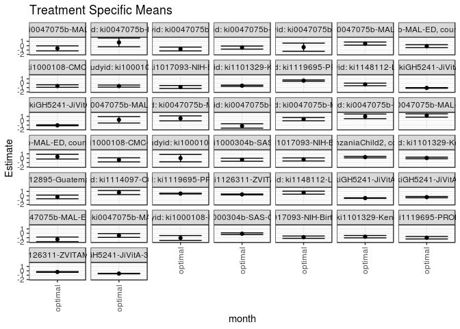

## Results Table

### Parameter: TSM

| agecat | studyid | country | intervention_level | baseline_level | estimate | ci_lower | ci_upper |
| --- | --- | --- | --- | --- | --- | --- | --- |
| Birth | ki0047075b-MAL-ED | BANGLADESH | optimal | observed | -1.3883113 | -1.9176210 | -0.8590015 |
| Birth | ki0047075b-MAL-ED | PERU | optimal | observed | -0.5045472 | -0.9320063 | -0.0770881 |
| Birth | ki1000108-IRC | INDIA | optimal | observed | -1.0725149 | -1.6282132 | -0.5168167 |
| Birth | ki1000304b-SAS-CompFeed | INDIA | optimal | observed | -0.0941808 | -0.2891424 | 0.1007809 |
| Birth | ki1017093-NIH-Birth | BANGLADESH | optimal | observed | -0.8910393 | -1.1524598 | -0.6296188 |
| Birth | ki1101329-Keneba | GAMBIA | optimal | observed | -0.7776531 | -1.0520901 | -0.5032162 |
| Birth | ki1119695-PROBIT | BELARUS | optimal | observed | -1.0161873 | -1.3005328 | -0.7318419 |
| Birth | ki1126311-ZVITAMBO | ZIMBABWE | optimal | observed | -0.2641628 | -0.3602395 | -0.1680862 |
| Birth | kiGH5241-JiVitA-3 | BANGLADESH | optimal | observed | -0.6343991 | -0.6920815 | -0.5767166 |
| 6 months | ki0047075b-MAL-ED | BANGLADESH | optimal | observed | 0.2079187 | -0.5274374 | 0.9432748 |
| 6 months | ki0047075b-MAL-ED | BRAZIL | optimal | observed | 0.5430252 | -0.0329012 | 1.1189515 |
| 6 months | ki0047075b-MAL-ED | INDIA | optimal | observed | -1.2003017 | -1.7028362 | -0.6977673 |
| 6 months | ki0047075b-MAL-ED | NEPAL | optimal | observed | 0.3558204 | -0.0247604 | 0.7364012 |
| 6 months | ki0047075b-MAL-ED | PERU | optimal | observed | 0.9961017 | 0.4567636 | 1.5354398 |
| 6 months | ki0047075b-MAL-ED | SOUTH AFRICA | optimal | observed | 1.1973928 | 0.8143087 | 1.5804769 |
| 6 months | ki0047075b-MAL-ED | TANZANIA, UNITED REPUBLIC OF | optimal | observed | 0.3619630 | -0.1810284 | 0.9049545 |
| 6 months | ki1000108-CMC-V-BCS-2002 | INDIA | optimal | observed | -0.3643965 | -0.8288531 | 0.1000602 |
| 6 months | ki1000108-IRC | INDIA | optimal | observed | 0.0287456 | -0.8132759 | 0.8707671 |
| 6 months | ki1000304b-SAS-CompFeed | INDIA | optimal | observed | -0.3378347 | -0.6848812 | 0.0092117 |
| 6 months | ki1017093-NIH-Birth | BANGLADESH | optimal | observed | -0.2770113 | -0.6345928 | 0.0805701 |
| 6 months | ki1066203-TanzaniaChild2 | TANZANIA, UNITED REPUBLIC OF | optimal | observed | 0.2575345 | 0.0866810 | 0.4283880 |
| 6 months | ki1101329-Keneba | GAMBIA | optimal | observed | 0.0652386 | -0.1116141 | 0.2420913 |
| 6 months | ki1112895-Guatemala BSC | GUATEMALA | optimal | observed | -0.2613922 | -0.6850501 | 0.1622658 |
| 6 months | ki1114097-CONTENT | PERU | optimal | observed | 0.7538663 | 0.2840621 | 1.2236705 |
| 6 months | ki1119695-PROBIT | BELARUS | optimal | observed | 0.4989186 | 0.4081384 | 0.5896989 |
| 6 months | ki1126311-ZVITAMBO | ZIMBABWE | optimal | observed | 0.3059580 | 0.2113696 | 0.4005463 |
| 6 months | ki1148112-LCNI-5 | MALAWI | optimal | observed | 0.7115637 | 0.3625057 | 1.0606216 |
| 6 months | kiGH5241-JiVitA-3 | BANGLADESH | optimal | observed | -0.5309957 | -0.5979214 | -0.4640699 |
| 6 months | kiGH5241-JiVitA-4 | BANGLADESH | optimal | observed | -0.3139941 | -0.4630750 | -0.1649132 |
| 24 months | ki0047075b-MAL-ED | BANGLADESH | optimal | observed | -0.6120897 | -1.1875427 | -0.0366366 |
| 24 months | ki0047075b-MAL-ED | BRAZIL | optimal | observed | 0.7514184 | -0.2577266 | 1.7605635 |
| 24 months | ki0047075b-MAL-ED | INDIA | optimal | observed | -0.7588526 | -1.2001171 | -0.3175881 |
| 24 months | ki0047075b-MAL-ED | NEPAL | optimal | observed | -0.4318915 | -0.7798664 | -0.0839165 |
| 24 months | ki0047075b-MAL-ED | PERU | optimal | observed | -0.3393673 | -1.2754429 | 0.5967082 |
| 24 months | ki0047075b-MAL-ED | SOUTH AFRICA | optimal | observed | 0.4844001 | 0.1374285 | 0.8313717 |
| 24 months | ki0047075b-MAL-ED | TANZANIA, UNITED REPUBLIC OF | optimal | observed | -0.1074461 | -0.4430243 | 0.2281321 |
| 24 months | ki1000108-CMC-V-BCS-2002 | INDIA | optimal | observed | -0.6432475 | -0.9336926 | -0.3528024 |
| 24 months | ki1000108-IRC | INDIA | optimal | observed | -0.6529581 | -0.8909588 | -0.4149574 |
| 24 months | ki1017093-NIH-Birth | BANGLADESH | optimal | observed | -0.8693921 | -1.2180294 | -0.5207548 |
| 24 months | ki1101329-Keneba | GAMBIA | optimal | observed | -0.5672114 | -0.7106291 | -0.4237937 |
| 24 months | ki1119695-PROBIT | BELARUS | optimal | observed | 0.5972361 | 0.4501209 | 0.7443513 |
| 24 months | ki1148112-LCNI-5 | MALAWI | optimal | observed | -0.2818385 | -0.5836097 | 0.0199327 |
| 24 months | kiGH5241-JiVitA-3 | BANGLADESH | optimal | observed | -1.0804587 | -1.1580495 | -1.0028680 |
| 24 months | kiGH5241-JiVitA-4 | BANGLADESH | optimal | observed | -1.0480253 | -1.1545905 | -0.9414600 |

### Parameter: E(Y)

| agecat | studyid | country | intervention_level | baseline_level | estimate | ci_lower | ci_upper |
| --- | --- | --- | --- | --- | --- | --- | --- |
| Birth | ki0047075b-MAL-ED | BANGLADESH | observed | observed | -0.9418605 | -1.0869834 | -0.7967375 |
| Birth | ki0047075b-MAL-ED | PERU | observed | observed | -0.0520175 | -0.1725298 | 0.0684947 |
| Birth | ki1000108-IRC | INDIA | observed | observed | -1.0105831 | -1.1973019 | -0.8238643 |
| Birth | ki1000304b-SAS-CompFeed | INDIA | observed | observed | -0.6700453 | -0.8474950 | -0.4925957 |
| Birth | ki1017093-NIH-Birth | BANGLADESH | observed | observed | -1.3499217 | -1.4444634 | -1.2553801 |
| Birth | ki1101329-Keneba | GAMBIA | observed | observed | -1.2349454 | -1.2972413 | -1.1726496 |
| Birth | ki1119695-PROBIT | BELARUS | observed | observed | -1.1448633 | -1.3544229 | -0.9353037 |
| Birth | ki1126311-ZVITAMBO | ZIMBABWE | observed | observed | -0.5154897 | -0.5413479 | -0.4896314 |
| Birth | kiGH5241-JiVitA-3 | BANGLADESH | observed | observed | -0.7778272 | -0.7968313 | -0.7588232 |
| 6 months | ki0047075b-MAL-ED | BANGLADESH | observed | observed | -0.1376763 | -0.2664642 | -0.0088885 |
| 6 months | ki0047075b-MAL-ED | BRAZIL | observed | observed | 0.9720774 | 0.8078144 | 1.1363403 |
| 6 months | ki0047075b-MAL-ED | INDIA | observed | observed | -0.7079979 | -0.8344175 | -0.5815783 |
| 6 months | ki0047075b-MAL-ED | NEPAL | observed | observed | 0.1104308 | -0.0208643 | 0.2417259 |
| 6 months | ki0047075b-MAL-ED | PERU | observed | observed | 1.0528816 | 0.9313005 | 1.1744626 |
| 6 months | ki0047075b-MAL-ED | SOUTH AFRICA | observed | observed | 0.5421785 | 0.3900443 | 0.6943126 |
| 6 months | ki0047075b-MAL-ED | TANZANIA, UNITED REPUBLIC OF | observed | observed | 0.5362213 | 0.4049390 | 0.6675036 |
| 6 months | ki1000108-CMC-V-BCS-2002 | INDIA | observed | observed | -0.5026766 | -0.6536848 | -0.3516685 |
| 6 months | ki1000108-IRC | INDIA | observed | observed | -0.5989297 | -0.7344491 | -0.4634104 |
| 6 months | ki1000304b-SAS-CompFeed | INDIA | observed | observed | -0.6657084 | -0.8024377 | -0.5289791 |
| 6 months | ki1017093-NIH-Birth | BANGLADESH | observed | observed | -0.4474038 | -0.5378167 | -0.3569909 |
| 6 months | ki1066203-TanzaniaChild2 | TANZANIA, UNITED REPUBLIC OF | observed | observed | 0.0809332 | 0.0282644 | 0.1336020 |
| 6 months | ki1101329-Keneba | GAMBIA | observed | observed | -0.1846038 | -0.2354782 | -0.1337293 |
| 6 months | ki1112895-Guatemala BSC | GUATEMALA | observed | observed | -0.0840134 | -0.1945572 | 0.0265305 |
| 6 months | ki1114097-CONTENT | PERU | observed | observed | 1.0684318 | 0.9515274 | 1.1853362 |
| 6 months | ki1119695-PROBIT | BELARUS | observed | observed | 0.5792439 | 0.5193388 | 0.6391490 |
| 6 months | ki1126311-ZVITAMBO | ZIMBABWE | observed | observed | 0.3105514 | 0.2848767 | 0.3362262 |
| 6 months | ki1148112-LCNI-5 | MALAWI | observed | observed | 0.4499404 | 0.3788501 | 0.5210308 |
| 6 months | kiGH5241-JiVitA-3 | BANGLADESH | observed | observed | -0.5935161 | -0.6130518 | -0.5739805 |
| 6 months | kiGH5241-JiVitA-4 | BANGLADESH | observed | observed | -0.3898055 | -0.4270507 | -0.3525603 |
| 24 months | ki0047075b-MAL-ED | BANGLADESH | observed | observed | -0.8192925 | -0.9412667 | -0.6973182 |
| 24 months | ki0047075b-MAL-ED | BRAZIL | observed | observed | 0.4626233 | 0.2567495 | 0.6684971 |
| 24 months | ki0047075b-MAL-ED | INDIA | observed | observed | -0.9516520 | -1.0670654 | -0.8362385 |
| 24 months | ki0047075b-MAL-ED | NEPAL | observed | observed | -0.3749123 | -0.4886073 | -0.2612173 |
| 24 months | ki0047075b-MAL-ED | PERU | observed | observed | 0.1111982 | -0.0118399 | 0.2342362 |
| 24 months | ki0047075b-MAL-ED | SOUTH AFRICA | observed | observed | 0.4090301 | 0.2879441 | 0.5301161 |
| 24 months | ki0047075b-MAL-ED | TANZANIA, UNITED REPUBLIC OF | observed | observed | 0.0547975 | -0.0703378 | 0.1799328 |
| 24 months | ki1000108-CMC-V-BCS-2002 | INDIA | observed | observed | -0.5571505 | -0.6585247 | -0.4557763 |
| 24 months | ki1000108-IRC | INDIA | observed | observed | -0.7458150 | -0.8368180 | -0.6548120 |
| 24 months | ki1017093-NIH-Birth | BANGLADESH | observed | observed | -0.9115790 | -1.0095022 | -0.8136559 |
| 24 months | ki1101329-Keneba | GAMBIA | observed | observed | -0.8099290 | -0.8570608 | -0.7627972 |
| 24 months | ki1119695-PROBIT | BELARUS | observed | observed | 0.6874295 | 0.5756922 | 0.7991668 |
| 24 months | ki1148112-LCNI-5 | MALAWI | observed | observed | -0.0477709 | -0.1296526 | 0.0341109 |
| 24 months | kiGH5241-JiVitA-3 | BANGLADESH | observed | observed | -1.2978031 | -1.3210763 | -1.2745298 |
| 24 months | kiGH5241-JiVitA-4 | BANGLADESH | observed | observed | -1.2231088 | -1.2549632 | -1.1912543 |

### Parameter: PAR

| agecat | studyid | country | intervention_level | baseline_level | estimate | ci_lower | ci_upper |
| --- | --- | --- | --- | --- | --- | --- | --- |
| Birth | ki0047075b-MAL-ED | BANGLADESH | optimal | observed | 0.4464508 | -0.0576610 | 0.9505627 |
| Birth | ki0047075b-MAL-ED | PERU | optimal | observed | 0.4525297 | 0.0371132 | 0.8679461 |
| Birth | ki1000108-IRC | INDIA | optimal | observed | 0.0619318 | -0.4799488 | 0.6038125 |
| Birth | ki1000304b-SAS-CompFeed | INDIA | optimal | observed | -0.5758646 | -0.7847183 | -0.3670108 |
| Birth | ki1017093-NIH-Birth | BANGLADESH | optimal | observed | -0.4588824 | -0.7148946 | -0.2028702 |
| Birth | ki1101329-Keneba | GAMBIA | optimal | observed | -0.4572923 | -0.7229683 | -0.1916163 |
| Birth | ki1119695-PROBIT | BELARUS | optimal | observed | -0.1286760 | -0.3018987 | 0.0445467 |
| Birth | ki1126311-ZVITAMBO | ZIMBABWE | optimal | observed | -0.2513268 | -0.3437721 | -0.1588816 |
| Birth | kiGH5241-JiVitA-3 | BANGLADESH | optimal | observed | -0.1434282 | -0.1965121 | -0.0903443 |
| 6 months | ki0047075b-MAL-ED | BANGLADESH | optimal | observed | -0.3455950 | -1.0595065 | 0.3683165 |
| 6 months | ki0047075b-MAL-ED | BRAZIL | optimal | observed | 0.4290522 | -0.1309336 | 0.9890380 |
| 6 months | ki0047075b-MAL-ED | INDIA | optimal | observed | 0.4923039 | 0.0190666 | 0.9655411 |
| 6 months | ki0047075b-MAL-ED | NEPAL | optimal | observed | -0.2453896 | -0.6192841 | 0.1285049 |
| 6 months | ki0047075b-MAL-ED | PERU | optimal | observed | 0.0567799 | -0.4523483 | 0.5659080 |
| 6 months | ki0047075b-MAL-ED | SOUTH AFRICA | optimal | observed | -0.6552144 | -1.0201533 | -0.2902754 |
| 6 months | ki0047075b-MAL-ED | TANZANIA, UNITED REPUBLIC OF | optimal | observed | 0.1742583 | -0.3425422 | 0.6910588 |
| 6 months | ki1000108-CMC-V-BCS-2002 | INDIA | optimal | observed | -0.1382802 | -0.5831165 | 0.3065561 |
| 6 months | ki1000108-IRC | INDIA | optimal | observed | -0.6276753 | -1.4441856 | 0.1888349 |
| 6 months | ki1000304b-SAS-CompFeed | INDIA | optimal | observed | -0.3278737 | -0.5557358 | -0.1000116 |
| 6 months | ki1017093-NIH-Birth | BANGLADESH | optimal | observed | -0.1703925 | -0.5129756 | 0.1721907 |
| 6 months | ki1066203-TanzaniaChild2 | TANZANIA, UNITED REPUBLIC OF | optimal | observed | -0.1766013 | -0.3430879 | -0.0101147 |
| 6 months | ki1101329-Keneba | GAMBIA | optimal | observed | -0.2498424 | -0.4205711 | -0.0791136 |
| 6 months | ki1112895-Guatemala BSC | GUATEMALA | optimal | observed | 0.1773788 | -0.2264196 | 0.5811772 |
| 6 months | ki1114097-CONTENT | PERU | optimal | observed | 0.3145655 | -0.1513237 | 0.7804547 |
| 6 months | ki1119695-PROBIT | BELARUS | optimal | observed | 0.0803252 | 0.0170857 | 0.1435648 |
| 6 months | ki1126311-ZVITAMBO | ZIMBABWE | optimal | observed | 0.0045935 | -0.0851711 | 0.0943580 |
| 6 months | ki1148112-LCNI-5 | MALAWI | optimal | observed | -0.2616233 | -0.6045178 | 0.0812713 |
| 6 months | kiGH5241-JiVitA-3 | BANGLADESH | optimal | observed | -0.0625205 | -0.1265786 | 0.0015377 |
| 6 months | kiGH5241-JiVitA-4 | BANGLADESH | optimal | observed | -0.0758114 | -0.2245262 | 0.0729034 |
| 24 months | ki0047075b-MAL-ED | BANGLADESH | optimal | observed | -0.2072028 | -0.7509585 | 0.3365529 |
| 24 months | ki0047075b-MAL-ED | BRAZIL | optimal | observed | -0.2887952 | -1.2664683 | 0.6888780 |
| 24 months | ki0047075b-MAL-ED | INDIA | optimal | observed | -0.1927994 | -0.6197879 | 0.2341892 |
| 24 months | ki0047075b-MAL-ED | NEPAL | optimal | observed | 0.0569792 | -0.2822158 | 0.3961742 |
| 24 months | ki0047075b-MAL-ED | PERU | optimal | observed | 0.4505655 | -0.4477623 | 1.3488933 |
| 24 months | ki0047075b-MAL-ED | SOUTH AFRICA | optimal | observed | -0.0753700 | -0.4119405 | 0.2612005 |
| 24 months | ki0047075b-MAL-ED | TANZANIA, UNITED REPUBLIC OF | optimal | observed | 0.1622436 | -0.1576280 | 0.4821152 |
| 24 months | ki1000108-CMC-V-BCS-2002 | INDIA | optimal | observed | 0.0860969 | -0.1941402 | 0.3663341 |
| 24 months | ki1000108-IRC | INDIA | optimal | observed | -0.0928569 | -0.3299531 | 0.1442393 |
| 24 months | ki1017093-NIH-Birth | BANGLADESH | optimal | observed | -0.0421869 | -0.3776482 | 0.2932744 |
| 24 months | ki1101329-Keneba | GAMBIA | optimal | observed | -0.2427176 | -0.3806428 | -0.1047924 |
| 24 months | ki1119695-PROBIT | BELARUS | optimal | observed | 0.0901934 | -0.0405701 | 0.2209570 |
| 24 months | ki1148112-LCNI-5 | MALAWI | optimal | observed | 0.2340677 | -0.0615055 | 0.5296408 |
| 24 months | kiGH5241-JiVitA-3 | BANGLADESH | optimal | observed | -0.2173444 | -0.2920909 | -0.1425978 |
| 24 months | kiGH5241-JiVitA-4 | BANGLADESH | optimal | observed | -0.1750835 | -0.2789552 | -0.0712118 |